# Bay Area Assignment 1

Emma Clark

11/12/2020

```r
setwd("~/Desktop/Working Directory/GitHub/Bay-Area-Future/data")
# electric data
years <- 2017:2020
quarters <- 1:4
type <- "Electric"

pge_elec <- NULL

for(quarter in quarters) {
  for(year in years){

    filename <-
      paste0("PGE_",
      year,
      "_Q",
      quarter,
      "_",
      type,
      "UsageByZip.csv"
    )

  if(quarter %in% 3:4 & year == 2020){
    next
  }

  temp <- read_csv(filename)

  pge_elec <- rbind(pge_elec,temp)
  # Note rbind requires field names to be consistent for every new thing that you add.

  saveRDS(pge_elec, "pge_elec.rds")
    }
  }
```

```r
setwd("~/Desktop/Working Directory/GitHub/Bay-Area-Future/data")
# gas data
years <- 2017:2020
quarters <- 1:4
type <- "Gas"

pge_gas <- NULL

for(quarter in quarters) {
  for(year in years){

    filename <-
      paste0("PGE_",
      year,
      "_Q",
      quarter,
      "_",
      type,
      "UsageByZip.csv"
    )

  if(quarter %in% 3:4 & year == 2020){
    next
  }

  temp <- read_csv(filename)

  pge_gas <- rbind(pge_gas,temp)
  # Note rbind requires field names to be consistent for every new thing that you add.

  saveRDS(pge_gas, "pge_gas.rds")
    }
  }
```

```r
# create new variable kBTU
pge_elec$TOTALKBTU <- pge_elec$TOTALKWH * 3.412
pge_gas$TOTALKBTU <- pge_gas$TOTALTHM * 100

# remove dissimilar columns to bind
pge_elec <-select(
    pge_elec,
    !c(TOTALKWH, AVERAGEKWH, COMBINED)
  )
pge_gas <- select(
    pge_gas,
    !c(TOTALTHM, AVERAGETHM, COMBINED)
)

# bind electric and gas datasets
pge_elec_gas <- rbind(pge_elec,pge_gas)

# create date column
pge_elec_gas$yearmon <- as.yearmon(paste(pge_elec_gas$YEAR, pge_elec_gas$MONTH), "%Y %m")
pge_elec_gas <- transform(pge_elec_gas, DATE = as.Date(yearmon, frac = 1))
```

```r
# Bay Area zip codes
bay_county_names <-
  c(
    "Alameda",
    "Contra Costa",
    "Marin",
    "Napa",
    "San Francisco",
    "San Mateo",
    "Santa Clara",
    "Solano",
    "Sonoma"
  )

bay_counties1 <- counties("CA", progress_bar = F)
bay_counties <- filter(bay_counties1, NAME %in% bay_county_names)

usa_zips <-
  zctas(cb = T, progress_bar = F)

bay_zips <-
  usa_zips %>%
  st_centroid() %>%
  .[bay_counties, ] %>%
  st_set_geometry(NULL) %>%
  left_join(usa_zips %>% select(GEOID10)) %>%
  st_as_sf()
```

```r
# pipeline
pge_final <-
  pge_elec_gas %>%
  filter(
    CUSTOMERCLASS %in%
      c("Elec- Residential","Elec- Commercial",
        "Gas- Residential","Gas- Commercial"),
    ZIPCODE %in% bay_zips$ZCTA5CE10
    ) %>%
  group_by(DATE, CUSTOMERCLASS
          )%>%
  summarize(
    TOTALKBTU =
      sum(
        TOTALKBTU,
        na.rm = T)
  )
```

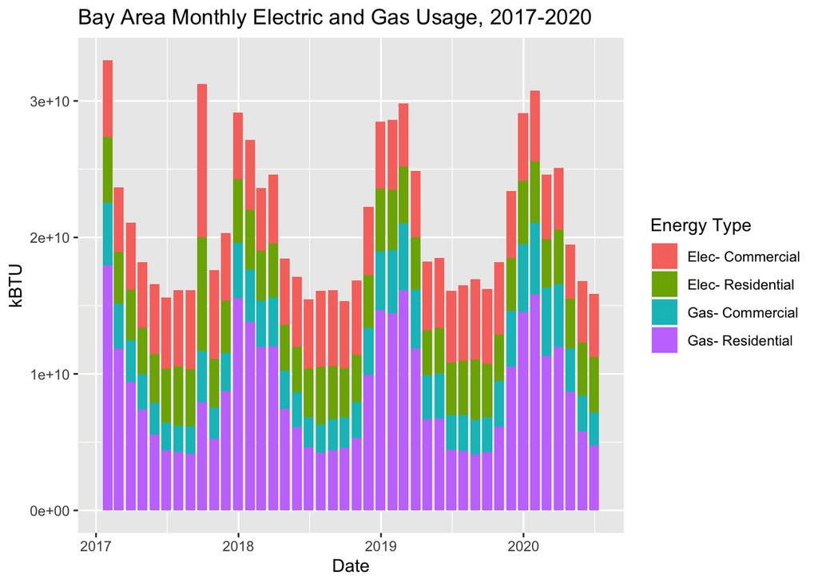

```r
# stacked pge chart
pge_chart <-
  pge_final %>%
  ggplot() +
  geom_bar(
    aes(
      x = DATE,
      y = TOTALKBTU,
      fill = CUSTOMERCLASS
    ),
    stat = "identity",
    position = "stack"
  ) +
  labs(
    x = "Date",
    y = "kBTU",
    title = "Bay Area Monthly Electric and Gas Usage, 2017-2020",
    fill = "Energy Type"
  )

pge_chart
```

```r
# covid dataset with geometries
pge_res_covid <-
  pge_elec_gas %>%
  filter(
    CUSTOMERCLASS %in% c("Elec- Residential"),
    ZIPCODE %in% bay_zips$ZCTA5CE10,
    YEAR %in% c("2019","2020"),
    MONTH %in% c("3","4","5","6")
    ) %>%
  select(
    !c(yearmon,DATE)
  ) %>%
  group_by(ZIPCODE,CUSTOMERCLASS,YEAR) %>%
  summarize(
    SPRINGKBTU = mean(TOTALKBTU, na.rm = T)
  ) %>%
  unite( #paste together multiple columns into one
    key,
    c(CUSTOMERCLASS,YEAR),
    sep = "-"
  ) %>%
  pivot_wider(
    names_from = key, #makes the values in key the name of columns
    values_from = SPRINGKBTU
  ) %>%
  rename(
    KBTU2019 = "Elec- Residential-2019",
    KBTU2020 = "Elec- Residential-2020"
  ) %>%
  mutate(
    KBTU_change =
      ((KBTU2020 - KBTU2019) / KBTU2019)*100
  ) %>%
   left_join(
    bay_zips %>%
      transmute(ZIPCODE = ZCTA5CE10 %>% as.numeric())
  )  %>%
  st_as_sf()
```

It’s difficult to pinpoint a direct change in energy consumption that would be attributable to the COVID-19 pandemic. Visually, the trend towards less energy consumption in the spring months of 2020 follow the trend lines of the previous years due to changes in seasonal usage. Though the usage numbers aren’t exactly the same and one would assume the pandemic changed energy consumption, it doesn’t seem immediately obvious that COVID-19 caused an immediate and noticeable enough shift in this bar chart.

```r
# mapping change in KBTU
res_pal <- colorNumeric(
  palette = "PuOr",
  domain =
    pge_res_covid$KBTU_change
)

leaflet() %>%
  addTiles() %>%
  addPolygons(
    data = pge_res_covid,
    fillColor = ~res_pal(KBTU_change),
    color = "white",
    opacity = 0.5,
    fillOpacity = 1,
    weight = 1,
    label = ~paste0(
      round(KBTU_change),
      " avg pct increase KBTU in ",
      ZIPCODE
    ),
    highlightOptions = highlightOptions(
      weight = 2,
      opacity = 1
    )
  ) %>%
  addLegend(
    data = pge_res_covid,
    pal = res_pal,
    values = ~KBTU_change,
    title = "Average Percent Increase<br>Residential Electric Usage<br>2019-2020"
  )
```

[interactive chart not shown]

For this analysis, I assumed that energy usage is highly seasonal. Therefore, to determine the change in energy consumption before and after the pandemic, I compared the same months from March to June in 2019 to 2020. Attributing any change in energy consumption from last year to this year implies the assumption that energy consumption this year would’ve been roughly the same as last year without the pandemic. Additionally, I wanted to focus only on residential electric usage to make the analysis more specific.

As you can see from the map, nearly every neighborhood in the Bay Area experienced an increase in residential electric consumption due to the pandemic, with increases ranging from 0-20%. The neighborhoods that experienced the greatest change in energy consumption are in Solano and Contra Costa county, as well as a couple neighborhoods in San Francisco and Marin county.